# Severe Weather Consequences in population health and economic aspects

Rolf Eleveld

Friday, April 24, 2015

# Severe Weather and Consequences for population health and economy

This research documents the consequences of Severe Weather as collected by NOAA. Special attention is placed on the population health consequences and the economic impact. The data is gathered from [NOAA Storm Data](https://d396qusza40orc.cloudfront.net/repdata%2Fdata%2FStormData.csv.bz2) for years 1950-2011. This research will show what type of events have had greatest impact on population health and which ones had the greatest economic impact.

# Data Processing

## downloading the data

```r
if (!file.exists("NOAA_Severe_Weather_Data.bz2")){
    setInternet2(use = TRUE)
    download.file("https://d396qusza40orc.cloudfront.net/repdata%2Fdata%2FStormData.csv.bz2",
                  "NOAA_Severe_Weather_Data.bz2",
                  mode="wb")
    }
# unzip the contents of the bzip2 file to a memory table
con <- bzfile('NOAA_Severe_Weather_Data.bz2', 'r')
NOAA <- read.csv(con, as.is=TRUE)
close(con)
```

## processing data

Adding a column where the total value is calculated based on Property and Crop multiplied by the Exp value

```r
#adding a function, as I could not solve this with a simple grep and sapply...
parseExp <- function(x) {
     exp <- 0
     if (!length(grep("[^[:digit:]]", as.character(x)))) {
         exp <- as.numeric(x);
     } else {
         if(x=="h" || x=="H"){
             exp <- 2
        } else { if (x=="k" || x=="K") {
            exp<-3
            } else { if (x=="m" || x=="M") {
                exp<-6
                } else {
                    if (x=="b" || x=="B") {
                        exp<-9
                    }
                }
            }
        }
     }
     result <- 10^exp
     return(result)
 }
#adding a function to easily process numbers without NA issues
parseNumber <- function(x){
    num <- 0
    if (!is.na(x) && is.numeric(x)){
        num <- as.numeric(x)
    }
    return(num)
}
#adding a column to NOAA with the total damages value
NOAA$TotalDamages <- parseNumber(NOAA$PROPDMG) * parseExp(NOAA$PROPDMGEXP) +
    parseNumber(NOAA$CROPDMG) * parseExp(NOAA$CROPDMGEXP)
```

## The 10 most costly event types

I take the 10 on average most costly event types and report these here.

```r
library(plyr)
library(dplyr)
#calculating mean damages
Noaa_damages_by_event <- ddply(NOAA,.(EVTYPE),summarise,Average_Damage=mean(TotalDamages) )
Noaa_top_10_damages <- Noaa_damages_by_event %>%
     arrange(desc(Average_Damage)) %>%
     head(10)
names(Noaa_top_10_damages)<-c("Event_Type", "Average_Damage_per_event")
Noaa_top_10_damages[,1]<-factor(Noaa_top_10_damages[,1])
Noaa_top_10_damages
```

```
##                        Event_Type Average_Damage_per_event
## 1                 COASTAL EROSION                   766000
## 2            HEAVY RAIN AND FLOOD                   600000
## 3          RIVER AND STREAM FLOOD                   600000
## 4                       Landslump                   570000
## 5           TROPICAL STORM GORDON                   500500
## 6           BLIZZARD/WINTER STORM                   500000
## 7                    FLASH FLOOD/                   500000
## 8  FLASH FLOODING/THUNDERSTORM WI                   500000
## 9               FLOOD/RIVER FLOOD                   500000
## 10                  FROST\\FREEZE                   500000
```

## Comparing injuriesis and deaths is hard

It is hard to sum fatalities and injuries therefore I will consider them separate

### Deadliest Event types

```r
Noaa_deaths_by_event <- ddply(NOAA,.(EVTYPE),summarise,Average_Deaths=mean(FATALITIES) )
Noaa_top_10_deaths <- Noaa_deaths_by_event %>%
     arrange(desc(Average_Deaths)) %>%
     head(10)
names(Noaa_top_10_deaths)<-c("Event_Type", "Average_deaths_per_event")
Noaa_top_10_deaths[,1]<-factor(Noaa_top_10_deaths[,1])
Noaa_top_10_deaths
```

```
##                    Event_Type Average_deaths_per_event
## 1  TORNADOES, TSTM WIND, HAIL                25.000000
## 2               COLD AND SNOW                14.000000
## 3       TROPICAL STORM GORDON                 8.000000
## 4       RECORD/EXCESSIVE HEAT                 5.666667
## 5                EXTREME HEAT                 4.363636
## 6           HEAT WAVE DROUGHT                 4.000000
## 7              HIGH WIND/SEAS                 4.000000
## 8               MARINE MISHAP                 3.500000
## 9               WINTER STORMS                 3.333333
## 10        Heavy surf and wind                 3.000000
```

### Events with most Injuries

```r
Noaa_injuries_by_event <- ddply(NOAA,.(EVTYPE),summarise,Average_Injuries=mean(INJURIES) )
Noaa_top_10_injuries <- Noaa_injuries_by_event %>%
     arrange(desc(Average_Injuries)) %>%
     head(10)
names(Noaa_top_10_injuries)<-c("Event_Type", "Average_injuries_per_event")
Noaa_top_10_injuries[,1]<-factor(Noaa_top_10_injuries[,1])
Noaa_top_10_injuries
```

```
##                 Event_Type Average_injuries_per_event
## 1                Heat Wave                   70.00000
## 2    TROPICAL STORM GORDON                   43.00000
## 3               WILD FIRES                   37.50000
## 4            THUNDERSTORMW                   27.00000
## 5       HIGH WIND AND SEAS                   20.00000
## 6          SNOW/HIGH WINDS                   18.00000
## 7          GLAZE/ICE STORM                   15.00000
## 8        HEAT WAVE DROUGHT                   15.00000
## 9  WINTER STORM HIGH WINDS                   15.00000
## 10       HURRICANE/TYPHOON                   14.48864
```

# Results

Below is a set of summary charts displaying the impact of the top 10 for: * Damages * Deaths * Injuries

[figure not shown]

```r
par(mar=c(8, 4, 2, 2) + 0.1)
par(las=2)
par(cex.axis = 0.5)
barplot(Noaa_top_10_damages$Average_Damage_per_event,
        names.arg=Noaa_top_10_deaths$Event_Type,
        main="Top 10 average damages",
        horiz=FALSE)
```

[figure not shown]

```r
barplot(Noaa_top_10_deaths$Average_deaths_per_event,
        names.arg=Noaa_top_10_damages$Event_Type,
        main="Top 10 average deaths",
        horiz=FALSE)
```

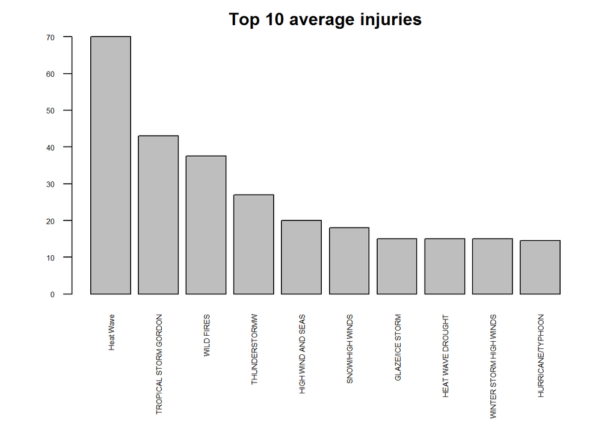

```r
barplot(Noaa_top_10_injuries$Average_injuries_per_event,
        names.arg=Noaa_top_10_injuries$Event_Type,
        main="Top 10 average injuries",
        horiz=FALSE)
```

No conclusions can be drawn based on these aggregate number over 61 years of archive. Further study will need to be done to the nature and combination of various weather events.